# Risk Factor Analysis

## Outcome Variable

**Outcome Variable:** ever_stunted

## Predictor Variables

**Intervention Variable:** tr.x

**Adjustment Set:**

unadjusted

## Stratifying Variables

The analysis was stratified on these variable(s):

- enstunt
- agecat
- studyid
- country

## Data Summary

| enstunt | agecat | studyid | country | tr.x | ever_stunted | n_cell | n |
| --- | --- | --- | --- | --- | --- | --- | --- |
| 1 | 0-6 months | ki1000107-Serrinha-VitA | BRAZIL | Control | 1 | 1 | 1 |
| 0 | 0-6 months | ki1000107-Serrinha-VitA | BRAZIL | Control | 0 | 5 | 9 |
| 0 | 0-6 months | ki1000107-Serrinha-VitA | BRAZIL | Other | 0 | 4 | 9 |
| 0 | 0-6 months | ki1000110-WASH-Bangladesh | BANGLADESH | Control | 0 | 34 | 201 |
| 0 | 0-6 months | ki1000110-WASH-Bangladesh | BANGLADESH | LNS | 0 | 61 | 201 |
| 0 | 0-6 months | ki1000110-WASH-Bangladesh | BANGLADESH | Other | 0 | 106 | 201 |
| 1 | 0-6 months | ki1000110-WASH-Bangladesh | BANGLADESH | Control | 1 | 6 | 23 |
| 1 | 0-6 months | ki1000110-WASH-Bangladesh | BANGLADESH | LNS | 1 | 7 | 23 |
| 1 | 0-6 months | ki1000110-WASH-Bangladesh | BANGLADESH | Other | 1 | 10 | 23 |
| 0 | 0-6 months | ki1000111-WASH-Kenya | KENYA | Control | 0 | 25 | 85 |
| 0 | 0-6 months | ki1000111-WASH-Kenya | KENYA | LNS | 0 | 23 | 85 |
| 0 | 0-6 months | ki1000111-WASH-Kenya | KENYA | Other | 0 | 37 | 85 |
| 1 | 0-6 months | ki1000111-WASH-Kenya | KENYA | Control | 1 | 2 | 7 |
| 1 | 0-6 months | ki1000111-WASH-Kenya | KENYA | Other | 1 | 5 | 7 |
| 0 | 0-6 months | ki1000125-AgaKhanUniv | PAKISTAN | Control | 0 | 79 | 184 |
| 0 | 0-6 months | ki1000125-AgaKhanUniv | PAKISTAN | Control | 1 | 19 | 184 |
| 0 | 0-6 months | ki1000125-AgaKhanUniv | PAKISTAN | Other | 0 | 69 | 184 |
| 0 | 0-6 months | ki1000125-AgaKhanUniv | PAKISTAN | Other | 1 | 17 | 184 |
| 1 | 0-6 months | ki1000125-AgaKhanUniv | PAKISTAN | Control | 0 | 14 | 81 |
| 1 | 0-6 months | ki1000125-AgaKhanUniv | PAKISTAN | Control | 1 | 21 | 81 |
| 1 | 0-6 months | ki1000125-AgaKhanUniv | PAKISTAN | Other | 0 | 28 | 81 |
| 1 | 0-6 months | ki1000125-AgaKhanUniv | PAKISTAN | Other | 1 | 18 | 81 |
| 1 | 0-6 months | ki1000304-EU | INDIA | Control | 1 | 4 | 7 |
| 1 | 0-6 months | ki1000304-EU | INDIA | Zinc | 1 | 3 | 7 |
| 0 | 0-6 months | ki1000304-EU | INDIA | Control | 0 | 2 | 7 |
| 0 | 0-6 months | ki1000304-EU | INDIA | Zinc | 0 | 5 | 7 |
| 0 | 0-6 months | ki1000304-Vitamin-B12 | INDIA | Control | 0 | 1 | 1 |
| 0 | 0-6 months | ki1000304-ZnMort | INDIA | Other | 0 | 38 | 80 |
| 0 | 0-6 months | ki1000304-ZnMort | INDIA | Zinc | 0 | 42 | 80 |
| 1 | 0-6 months | ki1000304-ZnMort | INDIA | Other | 1 | 28 | 54 |

[output cut: 417 more lines]

The following strata were considered:

- enstunt: 0, agecat: 0-24 months, studyid: ki1000107-Serrinha-VitA, country: BRAZIL
- enstunt: 0, agecat: 0-24 months, studyid: ki1000110-WASH-Bangladesh, country: BANGLADESH
- enstunt: 0, agecat: 0-24 months, studyid: ki1000111-WASH-Kenya, country: KENYA
- enstunt: 0, agecat: 0-24 months, studyid: ki1000125-AgaKhanUniv, country: PAKISTAN
- enstunt: 0, agecat: 0-24 months, studyid: ki1000304-EU, country: INDIA
- enstunt: 0, agecat: 0-24 months, studyid: ki1000304-Vitamin-B12, country: INDIA
- enstunt: 0, agecat: 0-24 months, studyid: ki1000304-ZnMort, country: INDIA
- enstunt: 0, agecat: 0-24 months, studyid: ki1000304b-SAS-CompFeed, country: INDIA
- enstunt: 0, agecat: 0-24 months, studyid: ki1000304b-SAS-FoodSuppl, country: INDIA
- enstunt: 0, agecat: 0-24 months, studyid: ki1066203-TanzaniaChild2, country: TANZANIA, UNITED REPUBLIC OF
- enstunt: 0, agecat: 0-24 months, studyid: ki1112895-Burkina Faso Zn, country: BURKINA FASO
- enstunt: 0, agecat: 0-24 months, studyid: ki1112895-Guatemala BSC, country: GUATEMALA
- enstunt: 0, agecat: 0-24 months, studyid: ki1112895-iLiNS-Zinc, country: BURKINA FASO
- enstunt: 0, agecat: 0-24 months, studyid: ki1119695-PROBIT, country: BELARUS
- enstunt: 0, agecat: 0-24 months, studyid: ki1126311-ZVITAMBO, country: ZIMBABWE
- enstunt: 0, agecat: 0-24 months, studyid: ki1135781-COHORTS, country: GUATEMALA
- enstunt: 0, agecat: 0-24 months, studyid: ki1148112-iLiNS-DOSE, country: MALAWI
- enstunt: 0, agecat: 0-24 months, studyid: ki1148112-iLiNS-DYAD-M, country: MALAWI
- enstunt: 0, agecat: 0-24 months, studyid: ki1148112-LCNI-5, country: MALAWI
- enstunt: 0, agecat: 0-24 months, studyid: kiGH5241-JiVitA-3, country: BANGLADESH
- enstunt: 0, agecat: 0-24 months, studyid: kiGH5241-JiVitA-4, country: BANGLADESH
- enstunt: 0, agecat: 0-6 months, studyid: ki1000107-Serrinha-VitA, country: BRAZIL
- enstunt: 0, agecat: 0-6 months, studyid: ki1000110-WASH-Bangladesh, country: BANGLADESH
- enstunt: 0, agecat: 0-6 months, studyid: ki1000111-WASH-Kenya, country: KENYA
- enstunt: 0, agecat: 0-6 months, studyid: ki1000125-AgaKhanUniv, country: PAKISTAN
- enstunt: 0, agecat: 0-6 months, studyid: ki1000304-EU, country: INDIA
- enstunt: 0, agecat: 0-6 months, studyid: ki1000304-Vitamin-B12, country: INDIA
- enstunt: 0, agecat: 0-6 months, studyid: ki1000304-ZnMort, country: INDIA
- enstunt: 0, agecat: 0-6 months, studyid: ki1000304b-SAS-CompFeed, country: INDIA
- enstunt: 0, agecat: 0-6 months, studyid: ki1000304b-SAS-FoodSuppl, country: INDIA
- enstunt: 0, agecat: 0-6 months, studyid: ki1066203-TanzaniaChild2, country: TANZANIA, UNITED REPUBLIC OF
- enstunt: 0, agecat: 0-6 months, studyid: ki1112895-Burkina Faso Zn, country: BURKINA FASO
- enstunt: 0, agecat: 0-6 months, studyid: ki1112895-Guatemala BSC, country: GUATEMALA
- enstunt: 0, agecat: 0-6 months, studyid: ki1119695-PROBIT, country: BELARUS
- enstunt: 0, agecat: 0-6 months, studyid: ki1126311-ZVITAMBO, country: ZIMBABWE
- enstunt: 0, agecat: 0-6 months, studyid: ki1135781-COHORTS, country: GUATEMALA
- enstunt: 0, agecat: 0-6 months, studyid: ki1148112-iLiNS-DOSE, country: MALAWI
- enstunt: 0, agecat: 0-6 months, studyid: ki1148112-iLiNS-DYAD-M, country: MALAWI
- enstunt: 0, agecat: 0-6 months, studyid: ki1148112-LCNI-5, country: MALAWI
- enstunt: 0, agecat: 0-6 months, studyid: kiGH5241-JiVitA-3, country: BANGLADESH
- enstunt: 0, agecat: 0-6 months, studyid: kiGH5241-JiVitA-4, country: BANGLADESH
- enstunt: 0, agecat: 6-24 months, studyid: ki1000107-Serrinha-VitA, country: BRAZIL
- enstunt: 0, agecat: 6-24 months, studyid: ki1000110-WASH-Bangladesh, country: BANGLADESH
- enstunt: 0, agecat: 6-24 months, studyid: ki1000111-WASH-Kenya, country: KENYA
- enstunt: 0, agecat: 6-24 months, studyid: ki1000125-AgaKhanUniv, country: PAKISTAN
- enstunt: 0, agecat: 6-24 months, studyid: ki1000304-EU, country: INDIA
- enstunt: 0, agecat: 6-24 months, studyid: ki1000304-Vitamin-B12, country: INDIA
- enstunt: 0, agecat: 6-24 months, studyid: ki1000304-ZnMort, country: INDIA
- enstunt: 0, agecat: 6-24 months, studyid: ki1000304b-SAS-CompFeed, country: INDIA
- enstunt: 0, agecat: 6-24 months, studyid: ki1000304b-SAS-FoodSuppl, country: INDIA
- enstunt: 0, agecat: 6-24 months, studyid: ki1066203-TanzaniaChild2, country: TANZANIA, UNITED REPUBLIC OF
- enstunt: 0, agecat: 6-24 months, studyid: ki1112895-Burkina Faso Zn, country: BURKINA FASO
- enstunt: 0, agecat: 6-24 months, studyid: ki1112895-Guatemala BSC, country: GUATEMALA
- enstunt: 0, agecat: 6-24 months, studyid: ki1112895-iLiNS-Zinc, country: BURKINA FASO
- enstunt: 0, agecat: 6-24 months, studyid: ki1119695-PROBIT, country: BELARUS
- enstunt: 0, agecat: 6-24 months, studyid: ki1126311-ZVITAMBO, country: ZIMBABWE
- enstunt: 0, agecat: 6-24 months, studyid: ki1135781-COHORTS, country: GUATEMALA
- enstunt: 0, agecat: 6-24 months, studyid: ki1148112-iLiNS-DOSE, country: MALAWI
- enstunt: 0, agecat: 6-24 months, studyid: ki1148112-iLiNS-DYAD-M, country: MALAWI
- enstunt: 0, agecat: 6-24 months, studyid: ki1148112-LCNI-5, country: MALAWI
- enstunt: 0, agecat: 6-24 months, studyid: kiGH5241-JiVitA-3, country: BANGLADESH
- enstunt: 0, agecat: 6-24 months, studyid: kiGH5241-JiVitA-4, country: BANGLADESH
- enstunt: 1, agecat: 0-24 months, studyid: ki1000107-Serrinha-VitA, country: BRAZIL
- enstunt: 1, agecat: 0-24 months, studyid: ki1000110-WASH-Bangladesh, country: BANGLADESH
- enstunt: 1, agecat: 0-24 months, studyid: ki1000111-WASH-Kenya, country: KENYA
- enstunt: 1, agecat: 0-24 months, studyid: ki1000125-AgaKhanUniv, country: PAKISTAN
- enstunt: 1, agecat: 0-24 months, studyid: ki1000304-EU, country: INDIA
- enstunt: 1, agecat: 0-24 months, studyid: ki1000304-Vitamin-B12, country: INDIA
- enstunt: 1, agecat: 0-24 months, studyid: ki1000304-ZnMort, country: INDIA
- enstunt: 1, agecat: 0-24 months, studyid: ki1000304b-SAS-CompFeed, country: INDIA
- enstunt: 1, agecat: 0-24 months, studyid: ki1000304b-SAS-FoodSuppl, country: INDIA
- enstunt: 1, agecat: 0-24 months, studyid: ki1066203-TanzaniaChild2, country: TANZANIA, UNITED REPUBLIC OF
- enstunt: 1, agecat: 0-24 months, studyid: ki1112895-Burkina Faso Zn, country: BURKINA FASO
- enstunt: 1, agecat: 0-24 months, studyid: ki1112895-Guatemala BSC, country: GUATEMALA
- enstunt: 1, agecat: 0-24 months, studyid: ki1112895-iLiNS-Zinc, country: BURKINA FASO
- enstunt: 1, agecat: 0-24 months, studyid: ki1119695-PROBIT, country: BELARUS
- enstunt: 1, agecat: 0-24 months, studyid: ki1126311-ZVITAMBO, country: ZIMBABWE
- enstunt: 1, agecat: 0-24 months, studyid: ki1135781-COHORTS, country: GUATEMALA
- enstunt: 1, agecat: 0-24 months, studyid: ki1148112-iLiNS-DOSE, country: MALAWI
- enstunt: 1, agecat: 0-24 months, studyid: ki1148112-iLiNS-DYAD-M, country: MALAWI
- enstunt: 1, agecat: 0-24 months, studyid: ki1148112-LCNI-5, country: MALAWI
- enstunt: 1, agecat: 0-24 months, studyid: kiGH5241-JiVitA-3, country: BANGLADESH
- enstunt: 1, agecat: 0-24 months, studyid: kiGH5241-JiVitA-4, country: BANGLADESH
- enstunt: 1, agecat: 0-6 months, studyid: ki1000107-Serrinha-VitA, country: BRAZIL
- enstunt: 1, agecat: 0-6 months, studyid: ki1000110-WASH-Bangladesh, country: BANGLADESH
- enstunt: 1, agecat: 0-6 months, studyid: ki1000111-WASH-Kenya, country: KENYA
- enstunt: 1, agecat: 0-6 months, studyid: ki1000125-AgaKhanUniv, country: PAKISTAN
- enstunt: 1, agecat: 0-6 months, studyid: ki1000304-EU, country: INDIA
- enstunt: 1, agecat: 0-6 months, studyid: ki1000304-ZnMort, country: INDIA
- enstunt: 1, agecat: 0-6 months, studyid: ki1000304b-SAS-CompFeed, country: INDIA
- enstunt: 1, agecat: 0-6 months, studyid: ki1000304b-SAS-FoodSuppl, country: INDIA
- enstunt: 1, agecat: 0-6 months, studyid: ki1066203-TanzaniaChild2, country: TANZANIA, UNITED REPUBLIC OF
- enstunt: 1, agecat: 0-6 months, studyid: ki1112895-Burkina Faso Zn, country: BURKINA FASO
- enstunt: 1, agecat: 0-6 months, studyid: ki1112895-Guatemala BSC, country: GUATEMALA
- enstunt: 1, agecat: 0-6 months, studyid: ki1119695-PROBIT, country: BELARUS
- enstunt: 1, agecat: 0-6 months, studyid: ki1126311-ZVITAMBO, country: ZIMBABWE
- enstunt: 1, agecat: 0-6 months, studyid: ki1135781-COHORTS, country: GUATEMALA
- enstunt: 1, agecat: 0-6 months, studyid: ki1148112-iLiNS-DOSE, country: MALAWI
- enstunt: 1, agecat: 0-6 months, studyid: ki1148112-iLiNS-DYAD-M, country: MALAWI
- enstunt: 1, agecat: 0-6 months, studyid: ki1148112-LCNI-5, country: MALAWI
- enstunt: 1, agecat: 0-6 months, studyid: kiGH5241-JiVitA-3, country: BANGLADESH
- enstunt: 1, agecat: 0-6 months, studyid: kiGH5241-JiVitA-4, country: BANGLADESH
- enstunt: 1, agecat: 6-24 months, studyid: ki1000107-Serrinha-VitA, country: BRAZIL
- enstunt: 1, agecat: 6-24 months, studyid: ki1000110-WASH-Bangladesh, country: BANGLADESH
- enstunt: 1, agecat: 6-24 months, studyid: ki1000111-WASH-Kenya, country: KENYA
- enstunt: 1, agecat: 6-24 months, studyid: ki1000125-AgaKhanUniv, country: PAKISTAN
- enstunt: 1, agecat: 6-24 months, studyid: ki1000304-Vitamin-B12, country: INDIA
- enstunt: 1, agecat: 6-24 months, studyid: ki1000304b-SAS-CompFeed, country: INDIA
- enstunt: 1, agecat: 6-24 months, studyid: ki1000304b-SAS-FoodSuppl, country: INDIA
- enstunt: 1, agecat: 6-24 months, studyid: ki1112895-Burkina Faso Zn, country: BURKINA FASO
- enstunt: 1, agecat: 6-24 months, studyid: ki1112895-Guatemala BSC, country: GUATEMALA
- enstunt: 1, agecat: 6-24 months, studyid: ki1112895-iLiNS-Zinc, country: BURKINA FASO
- enstunt: 1, agecat: 6-24 months, studyid: ki1119695-PROBIT, country: BELARUS
- enstunt: 1, agecat: 6-24 months, studyid: ki1126311-ZVITAMBO, country: ZIMBABWE
- enstunt: 1, agecat: 6-24 months, studyid: ki1135781-COHORTS, country: GUATEMALA
- enstunt: 1, agecat: 6-24 months, studyid: ki1148112-iLiNS-DOSE, country: MALAWI
- enstunt: 1, agecat: 6-24 months, studyid: ki1148112-iLiNS-DYAD-M, country: MALAWI
- enstunt: 1, agecat: 6-24 months, studyid: ki1148112-LCNI-5, country: MALAWI
- enstunt: 1, agecat: 6-24 months, studyid: kiGH5241-JiVitA-3, country: BANGLADESH
- enstunt: 1, agecat: 6-24 months, studyid: kiGH5241-JiVitA-4, country: BANGLADESH

### Dropped Strata

Some strata were dropped due to rare outcomes:

- enstunt: 1, agecat: 0-6 months, studyid: ki1000107-Serrinha-VitA, country: BRAZIL
- enstunt: 0, agecat: 0-6 months, studyid: ki1000107-Serrinha-VitA, country: BRAZIL
- enstunt: 1, agecat: 0-6 months, studyid: ki1000111-WASH-Kenya, country: KENYA
- enstunt: 1, agecat: 0-6 months, studyid: ki1000304-EU, country: INDIA
- enstunt: 0, agecat: 0-6 months, studyid: ki1000304-EU, country: INDIA
- enstunt: 0, agecat: 0-6 months, studyid: ki1000304-Vitamin-B12, country: INDIA
- enstunt: 0, agecat: 0-6 months, studyid: ki1066203-TanzaniaChild2, country: TANZANIA, UNITED REPUBLIC OF
- enstunt: 1, agecat: 0-6 months, studyid: ki1066203-TanzaniaChild2, country: TANZANIA, UNITED REPUBLIC OF
- enstunt: 1, agecat: 0-6 months, studyid: ki1135781-COHORTS, country: GUATEMALA
- enstunt: 0, agecat: 0-6 months, studyid: ki1148112-iLiNS-DYAD-M, country: MALAWI
- enstunt: 1, agecat: 0-6 months, studyid: ki1148112-iLiNS-DYAD-M, country: MALAWI
- enstunt: 1, agecat: 6-24 months, studyid: ki1000107-Serrinha-VitA, country: BRAZIL
- enstunt: 1, agecat: 6-24 months, studyid: ki1000125-AgaKhanUniv, country: PAKISTAN
- enstunt: 0, agecat: 6-24 months, studyid: ki1000304-EU, country: INDIA
- enstunt: 1, agecat: 6-24 months, studyid: ki1000304b-SAS-FoodSuppl, country: INDIA
- enstunt: 0, agecat: 6-24 months, studyid: ki1066203-TanzaniaChild2, country: TANZANIA, UNITED REPUBLIC OF
- enstunt: 1, agecat: 6-24 months, studyid: ki1112895-Burkina Faso Zn, country: BURKINA FASO
- enstunt: 1, agecat: 6-24 months, studyid: ki1112895-Guatemala BSC, country: GUATEMALA
- enstunt: 1, agecat: 6-24 months, studyid: ki1112895-iLiNS-Zinc, country: BURKINA FASO
- enstunt: 1, agecat: 6-24 months, studyid: ki1119695-PROBIT, country: BELARUS
- enstunt: 1, agecat: 6-24 months, studyid: ki1135781-COHORTS, country: GUATEMALA
- enstunt: 1, agecat: 6-24 months, studyid: ki1148112-iLiNS-DYAD-M, country: MALAWI
- enstunt: 1, agecat: 0-24 months, studyid: ki1000110-WASH-Bangladesh, country: BANGLADESH
- enstunt: 1, agecat: 0-24 months, studyid: ki1000111-WASH-Kenya, country: KENYA
- enstunt: 0, agecat: 0-24 months, studyid: ki1000304-EU, country: INDIA
- enstunt: 0, agecat: 0-24 months, studyid: ki1066203-TanzaniaChild2, country: TANZANIA, UNITED REPUBLIC OF
- enstunt: 1, agecat: 0-24 months, studyid: ki1066203-TanzaniaChild2, country: TANZANIA, UNITED REPUBLIC OF
- enstunt: 1, agecat: 0-24 months, studyid: ki1119695-PROBIT, country: BELARUS
- enstunt: 1, agecat: 0-24 months, studyid: ki1135781-COHORTS, country: GUATEMALA
- enstunt: 1, agecat: 0-24 months, studyid: ki1148112-iLiNS-DYAD-M, country: MALAWI

## Methods Detail

We’re interested in the causal parameters $E[Y_a]$ for all values of $a \in \mathcal{A}$. These parameters represent the mean outcome if, possibly contrary to fact, we intervened to set all units to have $A=a$. Under the randomization and positivity assumptions, these are identified by the statistical parameters $\psi_a=E_W[E_{Y|A,W}(Y|A=a,W)]$. In addition, we’re interested in the mean of $Y$, $E[Y]$ under no intervention (the observed mean). We will estimate these parameters by using SuperLearner to fit the relevant likelihood factors – $E_{Y|A,W}(Y|A=a,W)$ and $p(A=a|W)$, and then updating our likelihood fit using a joint TMLE.

For unadjusted analyses ($W=\{\}$), initial likelihoods were estimated using Lrnr_glm to estimate the simple $E(Y|A)$ and Lrnr_mean to estimate $p(A)$. For adjusted analyses, a small library containing Lrnr_glmnet, Lrnr_xgboost, and Lrnr_mean was used.

Having estimated these parameters, we will then use the delta method to estimate relative risks and attributable risks relative to a prespecified baseline level of $A$.

[output not shown]

[output cut: 155 more lines]

[output not shown]

# Results Detail

## Results Plots

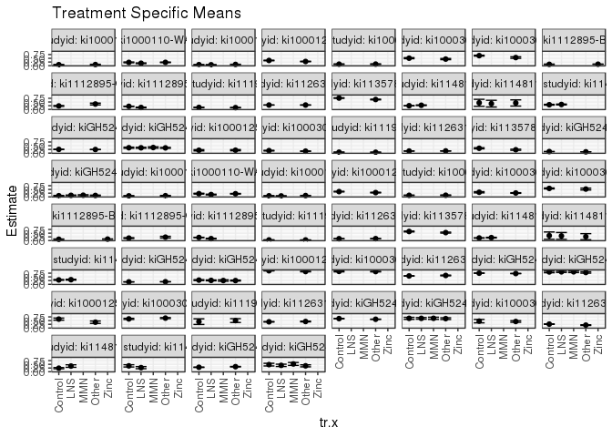

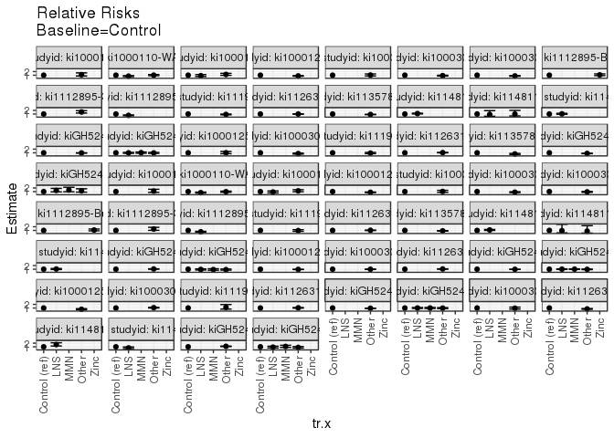

[figure not shown]

[figure not shown]

## Results Table

### Parameter: TSM

| enstunt | agecat | studyid | country | intervention_level | baseline_level | estimate | ci_lower | ci_upper |
| --- | --- | --- | --- | --- | --- | --- | --- | --- |
| 0 | 0-24 months | ki1000107-Serrinha-VitA | BRAZIL | Control | NA | 0.0673575 | 0.0491343 | 0.0855808 |
| 0 | 0-24 months | ki1000107-Serrinha-VitA | BRAZIL | Other | NA | 0.0769231 | 0.0581091 | 0.0957370 |
| 0 | 0-24 months | ki1000110-WASH-Bangladesh | BANGLADESH | Control | NA | 0.2227433 | 0.1948166 | 0.2506699 |
| 0 | 0-24 months | ki1000110-WASH-Bangladesh | BANGLADESH | LNS | NA | 0.1652361 | 0.1413890 | 0.1890831 |
| 0 | 0-24 months | ki1000110-WASH-Bangladesh | BANGLADESH | Other | NA | 0.2252405 | 0.2057601 | 0.2447209 |
| 0 | 0-24 months | ki1000111-WASH-Kenya | KENYA | Control | NA | 0.0702076 | 0.0578332 | 0.0825819 |
| 0 | 0-24 months | ki1000111-WASH-Kenya | KENYA | LNS | NA | 0.0613953 | 0.0470438 | 0.0757469 |
| 0 | 0-24 months | ki1000111-WASH-Kenya | KENYA | Other | NA | 0.0848367 | 0.0727765 | 0.0968968 |
| 0 | 0-24 months | ki1000125-AgaKhanUniv | PAKISTAN | Control | NA | 0.3531599 | 0.3330876 | 0.3732321 |
| 0 | 0-24 months | ki1000125-AgaKhanUniv | PAKISTAN | Other | NA | 0.2844037 | 0.2653350 | 0.3034723 |
| 0 | 0-24 months | ki1000304-Vitamin-B12 | INDIA | Control | NA | 0.1034483 | 0.0842067 | 0.1226898 |
| 0 | 0-24 months | ki1000304-Vitamin-B12 | INDIA | Other | NA | 0.1078838 | 0.0879062 | 0.1278614 |
| 0 | 0-24 months | ki1000304b-SAS-CompFeed | INDIA | Control | NA | 0.5062112 | 0.4697065 | 0.5427159 |
| 0 | 0-24 months | ki1000304b-SAS-CompFeed | INDIA | Other | NA | 0.4456522 | 0.4042055 | 0.4870988 |
| 0 | 0-24 months | ki1000304b-SAS-FoodSuppl | INDIA | Control | NA | 0.6774194 | 0.6485044 | 0.7063343 |
| 0 | 0-24 months | ki1000304b-SAS-FoodSuppl | INDIA | Other | NA | 0.5478723 | 0.4942646 | 0.6014801 |
| 0 | 0-24 months | ki1112895-Burkina Faso Zn | BURKINA FASO | Control | NA | 0.0913866 | 0.0730802 | 0.1096929 |
| 0 | 0-24 months | ki1112895-Burkina Faso Zn | BURKINA FASO | Zinc | NA | 0.1001407 | 0.0911297 | 0.1091517 |
| 0 | 0-24 months | ki1112895-Guatemala BSC | GUATEMALA | Control | NA | 0.2340426 | 0.2047924 | 0.2632927 |
| 0 | 0-24 months | ki1112895-Guatemala BSC | GUATEMALA | Other | NA | 0.3648649 | 0.3058502 | 0.4238795 |
| 0 | 0-24 months | ki1112895-iLiNS-Zinc | BURKINA FASO | Control | NA | 0.2073365 | 0.1956984 | 0.2189747 |
| 0 | 0-24 months | ki1112895-iLiNS-Zinc | BURKINA FASO | LNS | NA | 0.1302682 | 0.1091845 | 0.1513519 |
| 0 | 0-24 months | ki1119695-PROBIT | BELARUS | Control | NA | 0.1360947 | 0.1229985 | 0.1491908 |
| 0 | 0-24 months | ki1119695-PROBIT | BELARUS | Other | NA | 0.1197292 | 0.1096060 | 0.1298525 |
| 0 | 0-24 months | ki1126311-ZVITAMBO | ZIMBABWE | Control | NA | 0.2947648 | 0.2903792 | 0.2991504 |
| 0 | 0-24 months | ki1126311-ZVITAMBO | ZIMBABWE | Other | NA | 0.2952977 | 0.2877371 | 0.3028583 |
| 0 | 0-24 months | ki1135781-COHORTS | GUATEMALA | Control | NA | 0.7647059 | 0.7448206 | 0.7845911 |
| 0 | 0-24 months | ki1135781-COHORTS | GUATEMALA | Other | NA | 0.6681922 | 0.6453476 | 0.6910368 |
| 0 | 0-24 months | ki1148112-iLiNS-DOSE | MALAWI | Control | NA | 0.2488038 | 0.2393990 | 0.2582086 |
| 0 | 0-24 months | ki1148112-iLiNS-DOSE | MALAWI | LNS | NA | 0.2797075 | 0.2573674 | 0.3020476 |

[output cut: 108 more lines]

### Parameter: E(Y)

| enstunt | agecat | studyid | country | intervention_level | baseline_level | estimate | ci_lower | ci_upper |
| --- | --- | --- | --- | --- | --- | --- | --- | --- |
| 0 | 0-24 months | ki1000107-Serrinha-VitA | BRAZIL | NA | NA | 0.0720000 | 0.0458029 | 0.0981971 |
| 0 | 0-24 months | ki1000110-WASH-Bangladesh | BANGLADESH | NA | NA | 0.2088964 | 0.1955257 | 0.2222671 |
| 0 | 0-24 months | ki1000111-WASH-Kenya | KENYA | NA | NA | 0.0745172 | 0.0670592 | 0.0819752 |
| 0 | 0-24 months | ki1000125-AgaKhanUniv | PAKISTAN | NA | NA | 0.3185596 | 0.2907980 | 0.3463211 |
| 0 | 0-24 months | ki1000304-Vitamin-B12 | INDIA | NA | NA | 0.1057082 | 0.0779705 | 0.1334460 |
| 0 | 0-24 months | ki1000304b-SAS-CompFeed | INDIA | NA | NA | 0.4739130 | 0.4135513 | 0.5342748 |
| 0 | 0-24 months | ki1000304b-SAS-FoodSuppl | INDIA | NA | NA | 0.5800000 | 0.5186962 | 0.6413038 |
| 0 | 0-24 months | ki1112895-Burkina Faso Zn | BURKINA FASO | NA | NA | 0.0985429 | 0.0904537 | 0.1066322 |
| 0 | 0-24 months | ki1112895-Guatemala BSC | GUATEMALA | NA | NA | 0.3333333 | 0.2669986 | 0.3996681 |
| 0 | 0-24 months | ki1112895-iLiNS-Zinc | BURKINA FASO | NA | NA | 0.1499593 | 0.1232769 | 0.1766416 |
| 0 | 0-24 months | ki1119695-PROBIT | BELARUS | NA | NA | 0.1277164 | 0.1101499 | 0.1452829 |
| 0 | 0-24 months | ki1126311-ZVITAMBO | ZIMBABWE | NA | NA | 0.2951634 | 0.2864229 | 0.3039040 |
| 0 | 0-24 months | ki1135781-COHORTS | GUATEMALA | NA | NA | 0.7147929 | 0.6843317 | 0.7452541 |
| 0 | 0-24 months | ki1148112-iLiNS-DOSE | MALAWI | NA | NA | 0.2747506 | 0.2505037 | 0.2989974 |
| 0 | 0-24 months | ki1148112-iLiNS-DYAD-M | MALAWI | NA | NA | 0.4237288 | 0.2951677 | 0.5522899 |
| 0 | 0-24 months | ki1148112-LCNI-5 | MALAWI | NA | NA | 0.3244275 | 0.2843046 | 0.3645504 |
| 0 | 0-24 months | kiGH5241-JiVitA-3 | BANGLADESH | NA | NA | 0.2470596 | 0.2386384 | 0.2554808 |
| 0 | 0-24 months | kiGH5241-JiVitA-4 | BANGLADESH | NA | NA | 0.3624587 | 0.3440538 | 0.3808635 |
| 0 | 0-6 months | ki1000125-AgaKhanUniv | PAKISTAN | NA | NA | 0.1956522 | 0.1381761 | 0.2531282 |
| 0 | 0-6 months | ki1000304b-SAS-CompFeed | INDIA | NA | NA | 0.1502591 | 0.1210593 | 0.1794589 |
| 0 | 0-6 months | ki1119695-PROBIT | BELARUS | NA | NA | 0.0617256 | 0.0505044 | 0.0729468 |
| 0 | 0-6 months | ki1126311-ZVITAMBO | ZIMBABWE | NA | NA | 0.1459727 | 0.1382689 | 0.1536766 |
| 0 | 0-6 months | ki1135781-COHORTS | GUATEMALA | NA | NA | 0.2744361 | 0.2207102 | 0.3281620 |
| 0 | 0-6 months | kiGH5241-JiVitA-3 | BANGLADESH | NA | NA | 0.0961466 | 0.0905115 | 0.1017816 |
| 0 | 0-6 months | kiGH5241-JiVitA-4 | BANGLADESH | NA | NA | 0.0930233 | 0.0808837 | 0.1051628 |
| 0 | 6-24 months | ki1000107-Serrinha-VitA | BRAZIL | NA | NA | 0.0720000 | 0.0458029 | 0.0981971 |
| 0 | 6-24 months | ki1000110-WASH-Bangladesh | BANGLADESH | NA | NA | 0.1952271 | 0.1820521 | 0.2084022 |
| 0 | 6-24 months | ki1000111-WASH-Kenya | KENYA | NA | NA | 0.0752986 | 0.0677443 | 0.0828529 |
| 0 | 6-24 months | ki1000125-AgaKhanUniv | PAKISTAN | NA | NA | 0.3187067 | 0.2876538 | 0.3497596 |
| 0 | 6-24 months | ki1000304-Vitamin-B12 | INDIA | NA | NA | 0.1057082 | 0.0779705 | 0.1334460 |
| 0 | 6-24 months | ki1000304b-SAS-CompFeed | INDIA | NA | NA | 0.2838828 | 0.2356290 | 0.3321366 |
| 0 | 6-24 months | ki1000304b-SAS-FoodSuppl | INDIA | NA | NA | 0.5346535 | 0.4656971 | 0.6036099 |
| 0 | 6-24 months | ki1112895-Burkina Faso Zn | BURKINA FASO | NA | NA | 0.0975422 | 0.0894836 | 0.1056009 |
| 0 | 6-24 months | ki1112895-Guatemala BSC | GUATEMALA | NA | NA | 0.2134146 | 0.1505163 | 0.2763130 |
| 0 | 6-24 months | ki1112895-iLiNS-Zinc | BURKINA FASO | NA | NA | 0.1499593 | 0.1232769 | 0.1766416 |
| 0 | 6-24 months | ki1119695-PROBIT | BELARUS | NA | NA | 0.0426843 | 0.0323952 | 0.0529733 |
| 0 | 6-24 months | ki1126311-ZVITAMBO | ZIMBABWE | NA | NA | 0.1295024 | 0.1223389 | 0.1366659 |
| 0 | 6-24 months | ki1135781-COHORTS | GUATEMALA | NA | NA | 0.5706107 | 0.5281885 | 0.6130329 |
| 0 | 6-24 months | ki1148112-iLiNS-DOSE | MALAWI | NA | NA | 0.1936090 | 0.1698561 | 0.2173619 |
| 0 | 6-24 months | ki1148112-iLiNS-DYAD-M | MALAWI | NA | NA | 0.3000000 | 0.1696183 | 0.4303817 |
| 0 | 6-24 months | ki1148112-LCNI-5 | MALAWI | NA | NA | 0.3027888 | 0.2625559 | 0.3430217 |
| 0 | 6-24 months | kiGH5241-JiVitA-3 | BANGLADESH | NA | NA | 0.1678956 | 0.1594055 | 0.1763858 |
| 0 | 6-24 months | kiGH5241-JiVitA-4 | BANGLADESH | NA | NA | 0.2635754 | 0.2461302 | 0.2810205 |
| 1 | 0-24 months | ki1000125-AgaKhanUniv | PAKISTAN | NA | NA | 0.8855219 | 0.8598958 | 0.9111479 |
| 1 | 0-24 months | ki1000304b-SAS-CompFeed | INDIA | NA | NA | 0.8627451 | 0.8223227 | 0.9031675 |
| 1 | 0-24 months | ki1126311-ZVITAMBO | ZIMBABWE | NA | NA | 0.5873544 | 0.5595115 | 0.6151974 |
| 1 | 0-24 months | kiGH5241-JiVitA-3 | BANGLADESH | NA | NA | 0.7374302 | 0.7250303 | 0.7498300 |
| 1 | 0-24 months | kiGH5241-JiVitA-4 | BANGLADESH | NA | NA | 0.8266485 | 0.8030205 | 0.8502766 |
| 1 | 0-6 months | ki1000125-AgaKhanUniv | PAKISTAN | NA | NA | 0.4814815 | 0.3719913 | 0.5909716 |
| 1 | 0-6 months | ki1000304b-SAS-CompFeed | INDIA | NA | NA | 0.6428571 | 0.5874562 | 0.6982581 |
| 1 | 0-6 months | ki1119695-PROBIT | BELARUS | NA | NA | 0.4516129 | 0.2223315 | 0.6808943 |
| 1 | 0-6 months | ki1126311-ZVITAMBO | ZIMBABWE | NA | NA | 0.4333333 | 0.4014682 | 0.4651984 |
| 1 | 0-6 months | kiGH5241-JiVitA-3 | BANGLADESH | NA | NA | 0.6123182 | 0.5973502 | 0.6272862 |
| 1 | 0-6 months | kiGH5241-JiVitA-4 | BANGLADESH | NA | NA | 0.6464724 | 0.6155921 | 0.6773526 |
| 1 | 6-24 months | ki1000304b-SAS-CompFeed | INDIA | NA | NA | 0.4489796 | 0.3175153 | 0.5804439 |
| 1 | 6-24 months | ki1126311-ZVITAMBO | ZIMBABWE | NA | NA | 0.2112125 | 0.1823075 | 0.2401176 |
| 1 | 6-24 months | ki1148112-iLiNS-DOSE | MALAWI | NA | NA | 0.3529412 | 0.2597423 | 0.4461400 |
| 1 | 6-24 months | ki1148112-LCNI-5 | MALAWI | NA | NA | 0.3333333 | 0.2280411 | 0.4386256 |
| 1 | 6-24 months | kiGH5241-JiVitA-3 | BANGLADESH | NA | NA | 0.3196656 | 0.2978439 | 0.3414873 |
| 1 | 6-24 months | kiGH5241-JiVitA-4 | BANGLADESH | NA | NA | 0.4470588 | 0.4062464 | 0.4878712 |

### Parameter: RR

| enstunt | agecat | studyid | country | intervention_level | baseline_level | estimate | ci_lower | ci_upper |
| --- | --- | --- | --- | --- | --- | --- | --- | --- |
| 0 | 0-24 months | ki1000107-Serrinha-VitA | BRAZIL | Control | Control | 1.0000000 | 1.0000000 | 1.0000000 |
| 0 | 0-24 months | ki1000107-Serrinha-VitA | BRAZIL | Other | Control | 1.1420118 | 0.7930093 | 1.6446099 |
| 0 | 0-24 months | ki1000110-WASH-Bangladesh | BANGLADESH | Control | Control | 1.0000000 | 1.0000000 | 1.0000000 |
| 0 | 0-24 months | ki1000110-WASH-Bangladesh | BANGLADESH | LNS | Control | 0.7418229 | 0.6127369 | 0.8981036 |
| 0 | 0-24 months | ki1000110-WASH-Bangladesh | BANGLADESH | Other | Control | 1.0112114 | 0.8683471 | 1.1775803 |
| 0 | 0-24 months | ki1000111-WASH-Kenya | KENYA | Control | Control | 1.0000000 | 1.0000000 | 1.0000000 |
| 0 | 0-24 months | ki1000111-WASH-Kenya | KENYA | LNS | Control | 0.8744833 | 0.6525418 | 1.1719112 |
| 0 | 0-24 months | ki1000111-WASH-Kenya | KENYA | Other | Control | 1.2083692 | 0.9635164 | 1.5154450 |
| 0 | 0-24 months | ki1000125-AgaKhanUniv | PAKISTAN | Control | Control | 1.0000000 | 1.0000000 | 1.0000000 |
| 0 | 0-24 months | ki1000125-AgaKhanUniv | PAKISTAN | Other | Control | 0.8053114 | 0.7375492 | 0.8792993 |
| 0 | 0-24 months | ki1000304-Vitamin-B12 | INDIA | Control | Control | 1.0000000 | 1.0000000 | 1.0000000 |
| 0 | 0-24 months | ki1000304-Vitamin-B12 | INDIA | Other | Control | 1.0428769 | 0.8021332 | 1.3558748 |
| 0 | 0-24 months | ki1000304b-SAS-CompFeed | INDIA | Control | Control | 1.0000000 | 1.0000000 | 1.0000000 |
| 0 | 0-24 months | ki1000304b-SAS-CompFeed | INDIA | Other | Control | 0.8803681 | 0.7826534 | 0.9902825 |
| 0 | 0-24 months | ki1000304b-SAS-FoodSuppl | INDIA | Control | Control | 1.0000000 | 1.0000000 | 1.0000000 |
| 0 | 0-24 months | ki1000304b-SAS-FoodSuppl | INDIA | Other | Control | 0.8087639 | 0.7268754 | 0.8998779 |
| 0 | 0-24 months | ki1112895-Burkina Faso Zn | BURKINA FASO | Control | Control | 1.0000000 | 1.0000000 | 1.0000000 |
| 0 | 0-24 months | ki1112895-Burkina Faso Zn | BURKINA FASO | Zinc | Control | 1.0957926 | 0.8797458 | 1.3648960 |
| 0 | 0-24 months | ki1112895-Guatemala BSC | GUATEMALA | Control | Control | 1.0000000 | 1.0000000 | 1.0000000 |
| 0 | 0-24 months | ki1112895-Guatemala BSC | GUATEMALA | Other | Control | 1.5589681 | 1.2707675 | 1.9125303 |
| 0 | 0-24 months | ki1112895-iLiNS-Zinc | BURKINA FASO | Control | Control | 1.0000000 | 1.0000000 | 1.0000000 |
| 0 | 0-24 months | ki1112895-iLiNS-Zinc | BURKINA FASO | LNS | Control | 0.6282935 | 0.5288898 | 0.7463801 |
| 0 | 0-24 months | ki1119695-PROBIT | BELARUS | Control | Control | 1.0000000 | 1.0000000 | 1.0000000 |
| 0 | 0-24 months | ki1119695-PROBIT | BELARUS | Other | Control | 0.8797496 | 0.7750355 | 0.9986115 |
| 0 | 0-24 months | ki1126311-ZVITAMBO | ZIMBABWE | Control | Control | 1.0000000 | 1.0000000 | 1.0000000 |
| 0 | 0-24 months | ki1126311-ZVITAMBO | ZIMBABWE | Other | Control | 1.0018080 | 0.9725769 | 1.0319176 |
| 0 | 0-24 months | ki1135781-COHORTS | GUATEMALA | Control | Control | 1.0000000 | 1.0000000 | 1.0000000 |
| 0 | 0-24 months | ki1135781-COHORTS | GUATEMALA | Other | Control | 0.8737898 | 0.8370516 | 0.9121405 |
| 0 | 0-24 months | ki1148112-iLiNS-DOSE | MALAWI | Control | Control | 1.0000000 | 1.0000000 | 1.0000000 |
| 0 | 0-24 months | ki1148112-iLiNS-DOSE | MALAWI | LNS | Control | 1.1242090 | 1.0291331 | 1.2280683 |

[output cut: 108 more lines]

### Parameter: PAR

| enstunt | agecat | studyid | country | intervention_level | baseline_level | estimate | ci_lower | ci_upper |
| --- | --- | --- | --- | --- | --- | --- | --- | --- |
| 0 | 0-24 months | ki1000107-Serrinha-VitA | BRAZIL | Control | NA | 0.0046425 | -0.0141777 | 0.0234627 |
| 0 | 0-24 months | ki1000110-WASH-Bangladesh | BANGLADESH | Control | NA | -0.0138469 | -0.0380149 | 0.0103212 |
| 0 | 0-24 months | ki1000111-WASH-Kenya | KENYA | Control | NA | 0.0043096 | -0.0058613 | 0.0144806 |
| 0 | 0-24 months | ki1000125-AgaKhanUniv | PAKISTAN | Control | NA | -0.0346003 | -0.0537787 | -0.0154219 |
| 0 | 0-24 months | ki1000304-Vitamin-B12 | INDIA | Control | NA | 0.0022600 | -0.0177187 | 0.0222386 |
| 0 | 0-24 months | ki1000304b-SAS-CompFeed | INDIA | Control | NA | -0.0322981 | -0.0799799 | 0.0153836 |
| 0 | 0-24 months | ki1000304b-SAS-FoodSuppl | INDIA | Control | NA | -0.0974194 | -0.1514756 | -0.0433631 |
| 0 | 0-24 months | ki1112895-Burkina Faso Zn | BURKINA FASO | Control | NA | 0.0071564 | -0.0095238 | 0.0238366 |
| 0 | 0-24 months | ki1112895-Guatemala BSC | GUATEMALA | Control | NA | 0.0992908 | 0.0397532 | 0.1588284 |
| 0 | 0-24 months | ki1112895-iLiNS-Zinc | BURKINA FASO | Control | NA | -0.0573773 | -0.0825700 | -0.0321845 |
| 0 | 0-24 months | ki1119695-PROBIT | BELARUS | Control | NA | -0.0083783 | -0.0192747 | 0.0025181 |
| 0 | 0-24 months | ki1126311-ZVITAMBO | ZIMBABWE | Control | NA | 0.0003987 | -0.0071620 | 0.0079593 |
| 0 | 0-24 months | ki1135781-COHORTS | GUATEMALA | Control | NA | -0.0499130 | -0.0729881 | -0.0268379 |
| 0 | 0-24 months | ki1148112-iLiNS-DOSE | MALAWI | Control | NA | 0.0259467 | 0.0035981 | 0.0482954 |
| 0 | 0-24 months | ki1148112-iLiNS-DYAD-M | MALAWI | Control | NA | -0.0207156 | -0.2160549 | 0.1746236 |
| 0 | 0-24 months | ki1148112-LCNI-5 | MALAWI | Control | NA | 0.0078252 | -0.0208861 | 0.0365364 |
| 0 | 0-24 months | kiGH5241-JiVitA-3 | BANGLADESH | Control | NA | -0.0042000 | -0.0099162 | 0.0015162 |
| 0 | 0-24 months | kiGH5241-JiVitA-4 | BANGLADESH | Control | NA | -0.0021140 | -0.0332724 | 0.0290445 |
| 0 | 0-6 months | ki1000125-AgaKhanUniv | PAKISTAN | Control | NA | 0.0017746 | -0.0376733 | 0.0412225 |
| 0 | 0-6 months | ki1000304b-SAS-CompFeed | INDIA | Control | NA | -0.0188586 | -0.0383352 | 0.0006180 |
| 0 | 0-6 months | ki1119695-PROBIT | BELARUS | Control | NA | -0.0025742 | -0.0098642 | 0.0047157 |
| 0 | 0-6 months | ki1126311-ZVITAMBO | ZIMBABWE | Control | NA | 0.0054482 | -0.0012562 | 0.0121527 |
| 0 | 0-6 months | ki1135781-COHORTS | GUATEMALA | Control | NA | -0.0535639 | -0.0907793 | -0.0163485 |
| 0 | 0-6 months | kiGH5241-JiVitA-3 | BANGLADESH | Control | NA | -0.0091166 | -0.0128115 | -0.0054217 |
| 0 | 0-6 months | kiGH5241-JiVitA-4 | BANGLADESH | Control | NA | 0.0177291 | -0.0005659 | 0.0360242 |
| 0 | 6-24 months | ki1000107-Serrinha-VitA | BRAZIL | Control | NA | 0.0046425 | -0.0141777 | 0.0234627 |
| 0 | 6-24 months | ki1000110-WASH-Bangladesh | BANGLADESH | Control | NA | -0.0188038 | -0.0426886 | 0.0050810 |
| 0 | 6-24 months | ki1000111-WASH-Kenya | KENYA | Control | NA | 0.0047104 | -0.0055663 | 0.0149871 |
| 0 | 6-24 months | ki1000125-AgaKhanUniv | PAKISTAN | Control | NA | -0.0346587 | -0.0564950 | -0.0128224 |
| 0 | 6-24 months | ki1000304-Vitamin-B12 | INDIA | Control | NA | 0.0022600 | -0.0177187 | 0.0222386 |
| 0 | 6-24 months | ki1000304b-SAS-CompFeed | INDIA | Control | NA | -0.0271408 | -0.0553955 | 0.0011139 |
| 0 | 6-24 months | ki1000304b-SAS-FoodSuppl | INDIA | Control | NA | -0.0335284 | -0.0946315 | 0.0275748 |
| 0 | 6-24 months | ki1112895-Burkina Faso Zn | BURKINA FASO | Control | NA | 0.0079743 | -0.0086020 | 0.0245506 |
| 0 | 6-24 months | ki1112895-Guatemala BSC | GUATEMALA | Control | NA | 0.0467480 | -0.0090905 | 0.1025865 |
| 0 | 6-24 months | ki1112895-iLiNS-Zinc | BURKINA FASO | Control | NA | -0.0573773 | -0.0825700 | -0.0321845 |
| 0 | 6-24 months | ki1119695-PROBIT | BELARUS | Control | NA | -0.0010233 | -0.0057262 | 0.0036795 |
| 0 | 6-24 months | ki1126311-ZVITAMBO | ZIMBABWE | Control | NA | 0.0031570 | -0.0030553 | 0.0093694 |
| 0 | 6-24 months | ki1135781-COHORTS | GUATEMALA | Control | NA | -0.0414583 | -0.0735126 | -0.0094039 |
| 0 | 6-24 months | ki1148112-iLiNS-DOSE | MALAWI | Control | NA | 0.0184678 | -0.0033806 | 0.0403162 |
| 0 | 6-24 months | ki1148112-iLiNS-DYAD-M | MALAWI | Control | NA | -0.0333333 | -0.2363014 | 0.1696347 |
| 0 | 6-24 months | ki1148112-LCNI-5 | MALAWI | Control | NA | 0.0072423 | -0.0216232 | 0.0361078 |
| 0 | 6-24 months | kiGH5241-JiVitA-3 | BANGLADESH | Control | NA | 0.0049095 | -0.0012672 | 0.0110862 |
| 0 | 6-24 months | kiGH5241-JiVitA-4 | BANGLADESH | Control | NA | -0.0191062 | -0.0479721 | 0.0097597 |
| 1 | 0-24 months | ki1000125-AgaKhanUniv | PAKISTAN | Control | NA | -0.0273701 | -0.0475642 | -0.0071760 |
| 1 | 0-24 months | ki1000304b-SAS-CompFeed | INDIA | Control | NA | -0.0068201 | -0.0271182 | 0.0134780 |
| 1 | 0-24 months | ki1126311-ZVITAMBO | ZIMBABWE | Control | NA | 0.0235960 | -0.0004915 | 0.0476835 |
| 1 | 0-24 months | kiGH5241-JiVitA-3 | BANGLADESH | Control | NA | -0.0122241 | -0.0215650 | -0.0028831 |
| 1 | 0-24 months | kiGH5241-JiVitA-4 | BANGLADESH | Control | NA | -0.0062282 | -0.0498556 | 0.0373993 |
| 1 | 0-6 months | ki1000125-AgaKhanUniv | PAKISTAN | Control | NA | -0.1185185 | -0.2022348 | -0.0348022 |
| 1 | 0-6 months | ki1000304b-SAS-CompFeed | INDIA | Control | NA | 0.0299539 | -0.0092911 | 0.0691989 |
| 1 | 0-6 months | ki1119695-PROBIT | BELARUS | Control | NA | 0.0230415 | -0.1072172 | 0.1533002 |
| 1 | 0-6 months | ki1126311-ZVITAMBO | ZIMBABWE | Control | NA | 0.0149233 | -0.0125866 | 0.0424331 |
| 1 | 0-6 months | kiGH5241-JiVitA-3 | BANGLADESH | Control | NA | -0.0211244 | -0.0321415 | -0.0101073 |
| 1 | 0-6 months | kiGH5241-JiVitA-4 | BANGLADESH | Control | NA | -0.0046180 | -0.0613560 | 0.0521201 |
| 1 | 6-24 months | ki1000304b-SAS-CompFeed | INDIA | Control | NA | -0.0144350 | -0.0705400 | 0.0416699 |
| 1 | 6-24 months | ki1126311-ZVITAMBO | ZIMBABWE | Control | NA | -0.0508196 | -0.0752955 | -0.0263437 |
| 1 | 6-24 months | ki1148112-iLiNS-DOSE | MALAWI | Control | NA | 0.1148459 | 0.0296080 | 0.2000839 |
| 1 | 6-24 months | ki1148112-LCNI-5 | MALAWI | Control | NA | -0.0614035 | -0.1340639 | 0.0112569 |
| 1 | 6-24 months | kiGH5241-JiVitA-3 | BANGLADESH | Control | NA | 0.0189608 | 0.0027555 | 0.0351661 |
| 1 | 6-24 months | kiGH5241-JiVitA-4 | BANGLADESH | Control | NA | -0.0312020 | -0.1070857 | 0.0446816 |

### Parameter: PAF

| enstunt | agecat | studyid | country | intervention_level | baseline_level | estimate | ci_lower | ci_upper |
| --- | --- | --- | --- | --- | --- | --- | --- | --- |
| 0 | 0-24 months | ki1000107-Serrinha-VitA | BRAZIL | Control | NA | 0.0644790 | -0.2157012 | 0.2800866 |
| 0 | 0-24 months | ki1000110-WASH-Bangladesh | BANGLADESH | Control | NA | -0.0662858 | -0.1884518 | 0.0433222 |
| 0 | 0-24 months | ki1000111-WASH-Kenya | KENYA | Control | NA | 0.0578342 | -0.0889188 | 0.1848094 |
| 0 | 0-24 months | ki1000125-AgaKhanUniv | PAKISTAN | Control | NA | -0.1086148 | -0.1777789 | -0.0435124 |
| 0 | 0-24 months | ki1000304-Vitamin-B12 | INDIA | Control | NA | 0.0213793 | -0.1822608 | 0.1899431 |
| 0 | 0-24 months | ki1000304b-SAS-CompFeed | INDIA | Control | NA | -0.0681520 | -0.1814182 | 0.0342550 |
| 0 | 0-24 months | ki1000304b-SAS-FoodSuppl | INDIA | Control | NA | -0.1679644 | -0.2824062 | -0.0637354 |
| 0 | 0-24 months | ki1112895-Burkina Faso Zn | BURKINA FASO | Control | NA | 0.0726220 | -0.1129775 | 0.2272711 |
| 0 | 0-24 months | ki1112895-Guatemala BSC | GUATEMALA | Control | NA | 0.2978723 | 0.1573377 | 0.4149694 |
| 0 | 0-24 months | ki1112895-iLiNS-Zinc | BURKINA FASO | Control | NA | -0.3826191 | -0.6343046 | -0.1696935 |
| 0 | 0-24 months | ki1119695-PROBIT | BELARUS | Control | NA | -0.0656005 | -0.1612449 | 0.0221662 |
| 0 | 0-24 months | ki1126311-ZVITAMBO | ZIMBABWE | Control | NA | 0.0013506 | -0.0245602 | 0.0266062 |
| 0 | 0-24 months | ki1135781-COHORTS | GUATEMALA | Control | NA | -0.0698286 | -0.1049850 | -0.0357908 |
| 0 | 0-24 months | ki1148112-iLiNS-DOSE | MALAWI | Control | NA | 0.0944375 | 0.0176221 | 0.1652464 |
| 0 | 0-24 months | ki1148112-iLiNS-DYAD-M | MALAWI | Control | NA | -0.0488889 | -0.6278291 | 0.3241502 |
| 0 | 0-24 months | ki1148112-LCNI-5 | MALAWI | Control | NA | 0.0241199 | -0.0662080 | 0.1067954 |
| 0 | 0-24 months | kiGH5241-JiVitA-3 | BANGLADESH | Control | NA | -0.0170001 | -0.0408085 | 0.0062637 |
| 0 | 0-24 months | kiGH5241-JiVitA-4 | BANGLADESH | Control | NA | -0.0058323 | -0.0955632 | 0.0765493 |
| 0 | 0-6 months | ki1000125-AgaKhanUniv | PAKISTAN | Control | NA | 0.0090703 | -0.2123013 | 0.1900184 |
| 0 | 0-6 months | ki1000304b-SAS-CompFeed | INDIA | Control | NA | -0.1255071 | -0.2820149 | 0.0118943 |
| 0 | 0-6 months | ki1119695-PROBIT | BELARUS | Control | NA | -0.0417044 | -0.1725743 | 0.0745592 |
| 0 | 0-6 months | ki1126311-ZVITAMBO | ZIMBABWE | Control | NA | 0.0373237 | -0.0079340 | 0.0805493 |
| 0 | 0-6 months | ki1135781-COHORTS | GUATEMALA | Control | NA | -0.1951781 | -0.3714221 | -0.0415835 |
| 0 | 0-6 months | kiGH5241-JiVitA-3 | BANGLADESH | Control | NA | -0.0948197 | -0.1379224 | -0.0533497 |
| 0 | 0-6 months | kiGH5241-JiVitA-4 | BANGLADESH | Control | NA | 0.1905882 | -0.0278547 | 0.3626070 |
| 0 | 6-24 months | ki1000107-Serrinha-VitA | BRAZIL | Control | NA | 0.0644790 | -0.2157012 | 0.2800866 |
| 0 | 6-24 months | ki1000110-WASH-Bangladesh | BANGLADESH | Control | NA | -0.0963174 | -0.2256584 | 0.0193745 |
| 0 | 6-24 months | ki1000111-WASH-Kenya | KENYA | Control | NA | 0.0625562 | -0.0842165 | 0.1894601 |
| 0 | 6-24 months | ki1000125-AgaKhanUniv | PAKISTAN | Control | NA | -0.1087479 | -0.1877763 | -0.0349776 |
| 0 | 6-24 months | ki1000304-Vitamin-B12 | INDIA | Control | NA | 0.0213793 | -0.1822608 | 0.1899431 |
| 0 | 6-24 months | ki1000304b-SAS-CompFeed | INDIA | Control | NA | -0.0956058 | -0.2110327 | 0.0088195 |
| 0 | 6-24 months | ki1000304b-SAS-FoodSuppl | INDIA | Control | NA | -0.0627104 | -0.1914400 | 0.0521105 |
| 0 | 6-24 months | ki1112895-Burkina Faso Zn | BURKINA FASO | Control | NA | 0.0817520 | -0.1048003 | 0.2368038 |
| 0 | 6-24 months | ki1112895-Guatemala BSC | GUATEMALA | Control | NA | 0.2190476 | -0.0173027 | 0.4004866 |
| 0 | 6-24 months | ki1112895-iLiNS-Zinc | BURKINA FASO | Control | NA | -0.3826191 | -0.6343046 | -0.1696935 |
| 0 | 6-24 months | ki1119695-PROBIT | BELARUS | Control | NA | -0.0239747 | -0.1434756 | 0.0830376 |
| 0 | 6-24 months | ki1126311-ZVITAMBO | ZIMBABWE | Control | NA | 0.0243781 | -0.0235692 | 0.0700795 |
| 0 | 6-24 months | ki1135781-COHORTS | GUATEMALA | Control | NA | -0.0726560 | -0.1347474 | -0.0139621 |
| 0 | 6-24 months | ki1148112-iLiNS-DOSE | MALAWI | Control | NA | 0.0953870 | -0.0127953 | 0.1920137 |
| 0 | 6-24 months | ki1148112-iLiNS-DYAD-M | MALAWI | Control | NA | -0.1111111 | -1.0420005 | 0.3954125 |
| 0 | 6-24 months | ki1148112-LCNI-5 | MALAWI | Control | NA | 0.0239186 | -0.0737420 | 0.1126966 |
| 0 | 6-24 months | kiGH5241-JiVitA-3 | BANGLADESH | Control | NA | 0.0292414 | -0.0071515 | 0.0643193 |
| 0 | 6-24 months | kiGH5241-JiVitA-4 | BANGLADESH | Control | NA | -0.0724886 | -0.1877801 | 0.0316121 |
| 1 | 0-24 months | ki1000125-AgaKhanUniv | PAKISTAN | Control | NA | -0.0309084 | -0.0546947 | -0.0076586 |
| 1 | 0-24 months | ki1000304b-SAS-CompFeed | INDIA | Control | NA | -0.0079051 | -0.0319141 | 0.0155452 |
| 1 | 0-24 months | ki1126311-ZVITAMBO | ZIMBABWE | Control | NA | 0.0401734 | -0.0000196 | 0.0787509 |
| 1 | 0-24 months | kiGH5241-JiVitA-3 | BANGLADESH | Control | NA | -0.0165766 | -0.0295357 | -0.0037805 |
| 1 | 0-24 months | kiGH5241-JiVitA-4 | BANGLADESH | Control | NA | -0.0075342 | -0.0616951 | 0.0438637 |
| 1 | 0-6 months | ki1000125-AgaKhanUniv | PAKISTAN | Control | NA | -0.2461538 | -0.4863567 | -0.0447690 |
| 1 | 0-6 months | ki1000304b-SAS-CompFeed | INDIA | Control | NA | 0.0465950 | -0.0134133 | 0.1030499 |
| 1 | 0-6 months | ki1119695-PROBIT | BELARUS | Control | NA | 0.0510204 | -0.2675869 | 0.2895459 |
| 1 | 0-6 months | ki1126311-ZVITAMBO | ZIMBABWE | Control | NA | 0.0344384 | -0.0288614 | 0.0938437 |
| 1 | 0-6 months | kiGH5241-JiVitA-3 | BANGLADESH | Control | NA | -0.0344991 | -0.0532878 | -0.0160455 |
| 1 | 0-6 months | kiGH5241-JiVitA-4 | BANGLADESH | Control | NA | -0.0071433 | -0.0988164 | 0.0768816 |
| 1 | 6-24 months | ki1000304b-SAS-CompFeed | INDIA | Control | NA | -0.0321508 | -0.1704395 | 0.0897990 |
| 1 | 6-24 months | ki1126311-ZVITAMBO | ZIMBABWE | Control | NA | -0.2406087 | -0.3942295 | -0.1039144 |
| 1 | 6-24 months | ki1148112-iLiNS-DOSE | MALAWI | Control | NA | 0.3253968 | 0.1364394 | 0.4730081 |
| 1 | 6-24 months | ki1148112-LCNI-5 | MALAWI | Control | NA | -0.1842105 | -0.4768911 | 0.0504685 |
| 1 | 6-24 months | kiGH5241-JiVitA-3 | BANGLADESH | Control | NA | 0.0593146 | 0.0103253 | 0.1058788 |
| 1 | 6-24 months | kiGH5241-JiVitA-4 | BANGLADESH | Control | NA | -0.0697941 | -0.2533179 | 0.0868563 |